# Introduction to Social Network Analysis - Lab 2

## 4.1 Regular Equivalence

### 4.1.1 REGE

REGE is actually a set of algorithms that compute similarities - or dissimilarities - between vertices that equate to regular equivalence.

`REGE`, `REGE.for` - Classical REGE or REGGE, as also implemented in Ucinet. Similarities in terms of regular equivalence are computed. The REGE.for is a wrapper for calling the FORTRAN subrutine written by White (1985a), modified to be called by R. The REGE does the same, however it is written in R. The functions with and without “.for” differ only in whether they are implemented in R of FORTRAN. Needless to say, the functions implemented in FORTRAN are much faster.

REGE.ow, REGE.ow.for - The above function, modified so that a best match is searched for each arc separately (and not for both arcs, if they exist, together).

REGE.ownm.for - The above function, modified so that a best match for an outgoing ties is searched on row-normalized network and for incoming ties on column-normalized network.

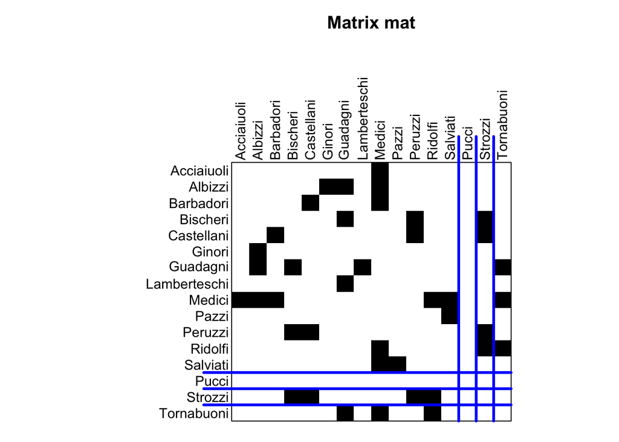

```r
mat <- as.matrix(igraph::get.adjacency(g)) # Extract the matrix in igraph (if you haven't already)
D<-blockmodeling::REGE(M=mat)$E
blockmodeling::plot.mat(mat, clu=cutree(hclust(d=as.dist(1-D),method="ward.D"),k=4))  #REGE returns similarities, which have to be converted to disimilarities
```

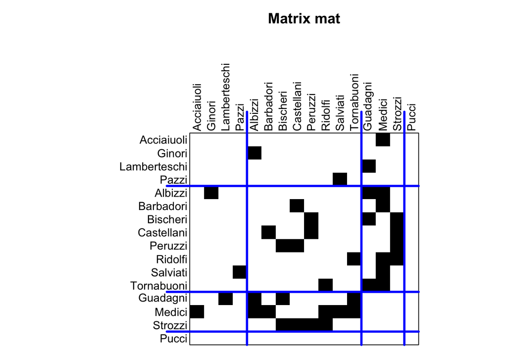

```r
# Try another variation of REGE
D2<-blockmodeling::REGE.ownm.for(M=mat)$E
blockmodeling::plot.mat(mat, clu=cutree(hclust(d=as.dist(1-D2),method="ward.D"),k=4))
```

# 5 Practicum: application to militarized interstate disputes

Militarized interstate disputes are widely thought to be less likely among democratic countries that have high levels of trade and extensive participation in international organizations.

Much of the statistical association typically reported in this literature apparently stems from three components: a) geographical proximity, b) dependence among militarized interstate disputes with the same initiator or target, and c) the higher-order dependencies in these dyadic data.

Once these are incorporated, covariates associated with the Kantian peace tripod (democracy, trade, and international governmental organizations) tend to lose most of their statistical power.

Despite high statistical significance and putative substantive importance, none of the variables representing the Kantian tripod is associated with any substantial degree of predictive power.

Using data from Peterson’s 2014 JCR [“Dyadic Trade, Exist costs and conflict”](http://sci-hub.se/10.1177/0022002713478794)

**Abstract:**

“Most studies of the link between dyadic trade and militarized conflict examine the extent of trade interaction. However, interaction measures do not account for the impact of cutting off trade (i.e., exit costs). In this article, I highlight the link between exit costs, the cost of conflict, and “the spoils of conquest,” arguing that one state’s exit costs are associated with higher incidence of dyadic conflict when its trade partner’s exit costs are low. However, its exit costs become less aggravating—and eventually pacifying—as its trade partner’s exit costs increase. I test this argument by estimating import demand and export supply elasticities, developing yearly exit cost measures for directed dyads, 1984–2000. Statistical tests confirm that unilaterally high exit costs are aggravating, but that jointly high exit costs are pacifying, a pattern most prominent for trade in strategic commodities.”

```r
peterson <- rio::import("./data/JCR_rep_data.dta")
#install.packages("countrycode")
library(countrycode)
peterson$cname1 <- countrycode(peterson$ccode1, "cown", "cowc")
peterson$cname2 <- countrycode(peterson$ccode2, "cown", "cowc")
peterson <- peterson %>% select(ccode1, ccode2, cname1, cname2, year, fcwinit, fcwongo, lndist, fincthc, finctlc, polity1_adj, polity2_adj, polity_int, s_wt_glo)
```

Description of variables

- `ccode1`, Correlates of War code number for state 1
- `ccode2`, Correlates of War code number for state 2
- `cname1`, Name State 1
- `cname2`, Name State 2
- `year`, Year of observation
- `fcwinit`, MID initiation t+1
- `fcwongo`, MID ongoing t+1
- `lndist`, natural log of distance
- `finctlc`, count of low conflict events t+1
- `fincthc`, count of high conflict events t+1
- `polity1_adj`, polity2 combined score for A (+10)
- `polity2_adj`, polity2 combined score for B (+10)
- `polity_int`, polity2 interaction of each state’s combined democracy–autocracy score(rescaled from 0 to 20) from the Polity IV project
- `s_wt_glo`, alliance similarity using Signorino and Ritter’s (1999) global weighted S score (accounts for similar foreign policy preferences)